# Question

A red triangle has coordinates $A(-2.73, -5.57)$, $B(-3.47, -6.36)$, and $C(-2.9, -8.76)$. The triangle is rotated 2.79 radians counterclockwise around the origin to produce a blue triangle $A'B'C'$.

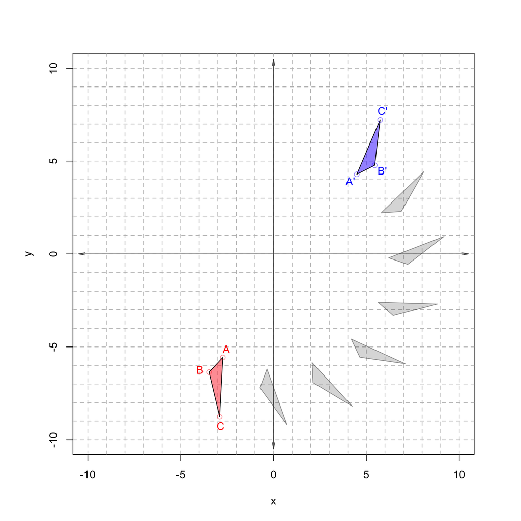

Find the $x$ coordinate of point B’. The tolerance is $\pm0.01$.

# Solution

Determine the [polar coordinates](https://en.wikipedia.org/wiki/Polar_coordinate_system) of the original point $B(-3.47, -6.36)$.

$$r_{B} =
\sqrt{(-3.47)^2+(-6.36)^2}$$

$$r_{B} = 7.2450328$$

Point $B$ is in quadrant $\mathrm{III}$. In quadrant $\mathrm{I}$ or $\mathrm{IV}$, the arctan function will provide a correct angle. For quadrant $\mathrm{II}$ or $\mathrm{III}$, add $\pi$ to get a correct angle. (Actually, Desmos allows $y$ and $x$ to be given as separate arguments to get a correct angle in any quadrant: `arctan(-6.36,-3.47)`.)

$$\theta_{B} =
\arctan\left(\frac{-6.36}{-3.47}\right)+\pi$$

$$\theta_{B} = 4.2129321$$

The new point, $B'$, will have the same distance from the origin, but its angle will be changed by adding 2.79 radians.

$$r_{B'} = 7.2450328$$

$$\theta_{B'} ~=~ \theta_{B}+2.79 ~=~
7.0029321$$

Calculate the Cartesian (rectangular) coordinates of point B’.

$$x_{B'} ~=~ 7.2450328 \cdot
\cos(7.0029321) ~=~ 5.4480666$$
$$y_{B'} ~=~ 7.2450328 \cdot \sin(7.0029321)
~=~ 4.7758842$$

The answer, rounded to the nearest hundredth, is 5.45.

# Meta-information

extype: num exsolution: 5.4480666 exname: rotate_point extol: 0.01